title: “Diabetes Prediction: Logistic Regression Analysis” author: “Kaushal” date: “24-03-2026” output:html_document

# Introduction

This report presents a logistic regression analysis of the **Diabetes Prediction Dataset** sourced from [Kaggle](https://www.kaggle.com/datasets/iammustafatz/diabetes-prediction-dataset).

**Study Design:** Cross-sectional observational study  
**Study Population:** ~100,000 patients with demographic, lifestyle, and clinical information  
**Outcome:** Binary diabetes status (0 = No Diabetes, 1 = Diabetes)

The aim is to build and evaluate a logistic regression model to predict the probability of diabetes based on 8 clinical and demographic predictors.

# Setup and Data Loading

```r
library(tidyverse)
library(caret)
library(pROC)
library(ggplot2)
library(gridExtra)
library(knitr)
library(kableExtra)
library(ResourceSelection)
```

```r
df <- read.csv("diabetes_prediction_dataset.csv", stringsAsFactors = FALSE)


dim(df)
```

```
## [1] 100000      9
```

```r
head(df)
```

```
##   gender age hypertension heart_disease smoking_history   bmi HbA1c_level
## 1 Female  80            0             1           never 25.19         6.6
## 2 Female  54            0             0         No Info 27.32         6.6
## 3   Male  28            0             0           never 27.32         5.7
## 4 Female  36            0             0         current 23.45         5.0
## 5   Male  76            1             1         current 20.14         4.8
## 6 Female  20            0             0           never 27.32         6.6
##   blood_glucose_level diabetes
## 1                 140        0
## 2                  80        0
## 3                 158        0
## 4                 155        0
## 5                 155        0
## 6                  85        0
```

# Data Inspection and Preprocessing

## Variable Overview

```r
str(df)
```

```
## 'data.frame':    100000 obs. of  9 variables:
##  $ gender             : chr  "Female" "Female" "Male" "Female" ...
##  $ age                : num  80 54 28 36 76 20 44 79 42 32 ...
##  $ hypertension       : int  0 0 0 0 1 0 0 0 0 0 ...
##  $ heart_disease      : int  1 0 0 0 1 0 0 0 0 0 ...
##  $ smoking_history    : chr  "never" "No Info" "never" "current" ...
##  $ bmi                : num  25.2 27.3 27.3 23.4 20.1 ...
##  $ HbA1c_level        : num  6.6 6.6 5.7 5 4.8 6.6 6.5 5.7 4.8 5 ...
##  $ blood_glucose_level: int  140 80 158 155 155 85 200 85 145 100 ...
##  $ diabetes           : int  0 0 0 0 0 0 1 0 0 0 ...
```

```r
summary(df)
```

```
##     gender               age         hypertension     heart_disease
##  Length:100000      Min.   : 0.08   Min.   :0.00000   Min.   :0.00000
##  Class :character   1st Qu.:24.00   1st Qu.:0.00000   1st Qu.:0.00000
##  Mode  :character   Median :43.00   Median :0.00000   Median :0.00000
##                     Mean   :41.89   Mean   :0.07485   Mean   :0.03942
##                     3rd Qu.:60.00   3rd Qu.:0.00000   3rd Qu.:0.00000
##                     Max.   :80.00   Max.   :1.00000   Max.   :1.00000
##  smoking_history         bmi         HbA1c_level    blood_glucose_level
##  Length:100000      Min.   :10.01   Min.   :3.500   Min.   : 80.0
##  Class :character   1st Qu.:23.63   1st Qu.:4.800   1st Qu.:100.0
##  Mode  :character   Median :27.32   Median :5.800   Median :140.0
##                     Mean   :27.32   Mean   :5.528   Mean   :138.1
##                     3rd Qu.:29.58   3rd Qu.:6.200   3rd Qu.:159.0
##                     Max.   :95.69   Max.   :9.000   Max.   :300.0
##     diabetes
##  Min.   :0.000
##  1st Qu.:0.000
##  Median :0.000
##  Mean   :0.085
##  3rd Qu.:0.000
##  Max.   :1.000
```

## Missing Data Assessment

```r
missing_summary <- data.frame(
  Variable = names(df),
  Missing_Count = colSums(is.na(df)),
  Missing_Percent = round(colSums(is.na(df)) / nrow(df) * 100, 2)
)

kable(missing_summary, row.names = FALSE,
      caption = "Missing Data Summary") %>%
  kable_styling(bootstrap_options = c("striped", "hover", "condensed"))
```

Missing Data Summary

| Variable | Missing_Count | Missing_Percent |
| --- | --- | --- |
| gender | 0 | 0 |
| age | 0 | 0 |
| hypertension | 0 | 0 |
| heart_disease | 0 | 0 |
| smoking_history | 0 | 0 |
| bmi | 0 | 0 |
| HbA1c_level | 0 | 0 |
| blood_glucose_level | 0 | 0 |
| diabetes | 0 | 0 |

## Encoding and Cleaning

```r
df <- df %>%
  mutate(
    gender = case_when(
      gender == "Male"   ~ 1,
      gender == "Female" ~ 0,
      TRUE               ~ NA_real_
    ),
    smoking_history = case_when(
      smoking_history == "never"   ~ 0,
      smoking_history == "former"  ~ 1,
      smoking_history == "current" ~ 2,
      smoking_history == "ever"    ~ 1,
      smoking_history == "not current" ~ 1,
      TRUE                         ~ NA_real_
    )
  )


df_clean <- df %>% drop_na()

cat("Observations after cleaning:", nrow(df_clean), "\n")
```

```
## Observations after cleaning: 64172
```

```r
cat("Diabetes cases:", sum(df_clean$diabetes), "\n")
```

```
## Diabetes cases: 7046
```

```r
cat("Prevalence:", round(mean(df_clean$diabetes) * 100, 2), "%\n")
```

```
## Prevalence: 10.98 %
```

# Exploratory Data Analysis

## Outcome Distribution

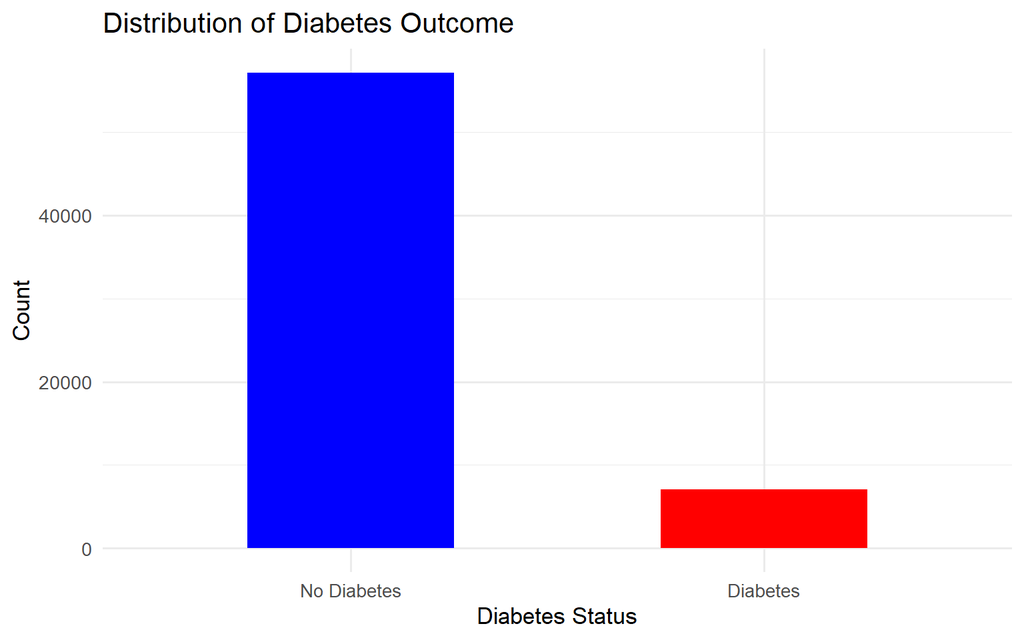

```r
ggplot(df_clean, aes(x = factor(diabetes), fill = factor(diabetes))) +
  geom_bar(width = 0.5, show.legend = FALSE) +
  scale_fill_manual(values = c("blue", "red")) +
  scale_x_discrete(labels = c("No Diabetes", "Diabetes")) +
  labs(title = "Distribution of Diabetes Outcome",
       x = "Diabetes Status", y = "Count") +
  theme_minimal(base_size = 13)
```

# Model Building

## Train-Test Split

```r
set.seed(42)

train_index <- createDataPartition(df_clean$diabetes, p = 0.8, list = FALSE)
train_data  <- df_clean[train_index, ]
test_data   <- df_clean[-train_index, ]

cat("Training set:", nrow(train_data), "observations\n")
```

```
## Training set: 51338 observations
```

```r
cat("Test set:", nrow(test_data), "observations\n")
```

```
## Test set: 12834 observations
```

## Logistic Regression Model

```r
model <- glm(
  diabetes ~ age + gender + hypertension + heart_disease +
             smoking_history + bmi + HbA1c_level + blood_glucose_level,
  data   = train_data,
  family = binomial(link = "logit")
)

summary(model)
```

```
##
## Call:
## glm(formula = diabetes ~ age + gender + hypertension + heart_disease +
##     smoking_history + bmi + HbA1c_level + blood_glucose_level,
##     family = binomial(link = "logit"), data = train_data)
##
## Coefficients:
##                       Estimate Std. Error z value Pr(>|z|)
## (Intercept)         -2.718e+01  3.676e-01 -73.925  < 2e-16 ***
## age                  4.952e-02  1.472e-03  33.648  < 2e-16 ***
## gender               3.022e-01  4.518e-02   6.688 2.26e-11 ***
## hypertension         7.332e-01  5.624e-02  13.037  < 2e-16 ***
## heart_disease        6.347e-01  7.640e-02   8.308  < 2e-16 ***
## smoking_history      3.347e-02  3.166e-02   1.057     0.29
## bmi                  8.881e-02  3.174e-03  27.980  < 2e-16 ***
## HbA1c_level          2.310e+00  4.487e-02  51.479  < 2e-16 ***
## blood_glucose_level  3.300e-02  6.031e-04  54.717  < 2e-16 ***
## ---
## Signif. codes:  0 '***' 0.001 '**' 0.01 '*' 0.05 '.' 0.1 ' ' 1
##
## (Dispersion parameter for binomial family taken to be 1)
##
##     Null deviance: 35566  on 51337  degrees of freedom
## Residual deviance: 14208  on 51329  degrees of freedom
## AIC: 14226
##
## Number of Fisher Scoring iterations: 8
```

## Odds Ratios and Confidence Intervals

```r
or_table <- data.frame(
  Predictor = names(coef(model)),
  Estimate  = round(coef(model), 4),
  OR        = round(exp(coef(model)), 4),
  CI_Lower  = round(exp(confint(model))[, 1], 4),
  CI_Upper  = round(exp(confint(model))[, 2], 4),
  P_value   = round(summary(model)$coefficients[, 4], 4)
)

kable(or_table, row.names = FALSE,
      caption = "Logistic Regression: Odds Ratios and 95% Confidence Intervals") %>%
  kable_styling(bootstrap_options = c("striped", "hover", "condensed")) %>%
  row_spec(which(or_table$P_value < 0.05), bold = TRUE, color = "white",
           background = "green")
```

Logistic Regression: Odds Ratios and 95% Confidence Intervals

| Predictor | Estimate | OR | CI_Lower | CI_Upper | P_value |
| --- | --- | --- | --- | --- | --- |
| (Intercept) | -27.1752 | 0.0000 | 0.0000 | 0.0000 | 0.0000 |
| age | 0.0495 | 1.0508 | 1.0478 | 1.0538 | 0.0000 |
| gender | 0.3022 | 1.3528 | 1.2382 | 1.4781 | 0.0000 |
| hypertension | 0.7332 | 2.0817 | 1.8640 | 2.3238 | 0.0000 |
| heart_disease | 0.6347 | 1.8865 | 1.6235 | 2.1904 | 0.0000 |
| smoking_history | 0.0335 | 1.0340 | 0.9717 | 1.1001 | 0.2905 |
| bmi | 0.0888 | 1.0929 | 1.0861 | 1.0997 | 0.0000 |
| HbA1c_level | 2.3100 | 10.0749 | 9.2381 | 11.0149 | 0.0000 |
| blood_glucose_level | 0.0330 | 1.0335 | 1.0323 | 1.0348 | 0.0000 |

# Model Evaluation

## Predictions on Test Set

```r
test_probs <- predict(model, newdata = test_data, type = "response")
test_preds <- ifelse(test_probs > 0.5, 1, 0)
```

## Confusion Matrix

```r
cm <- confusionMatrix(factor(test_preds), factor(test_data$diabetes),
                      positive = "1")
print(cm)
```

```
## Confusion Matrix and Statistics
##
##           Reference
## Prediction     0     1
##          0 11286   515
##          1   146   887
##
##                Accuracy : 0.9485
##                  95% CI : (0.9445, 0.9523)
##     No Information Rate : 0.8908
##     P-Value [Acc > NIR] : < 2.2e-16
##
##                   Kappa : 0.7008
##
##  Mcnemar's Test P-Value : < 2.2e-16
##
##             Sensitivity : 0.63267
##             Specificity : 0.98723
##          Pos Pred Value : 0.85866
##          Neg Pred Value : 0.95636
##              Prevalence : 0.10924
##          Detection Rate : 0.06911
##    Detection Prevalence : 0.08049
##       Balanced Accuracy : 0.80995
##
##        'Positive' Class : 1
##
```

## ROC Curve and AUC

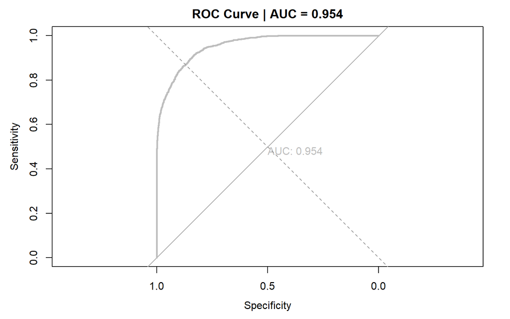

```r
roc_obj <- roc(test_data$diabetes, test_probs)

plot(roc_obj,
     col = "grey", lwd = 2.5,
     main = paste("ROC Curve | AUC =", round(auc(roc_obj), 3)),
     print.auc = TRUE)
abline(a = 0, b = 1, lty = 2, col = "grey60")
```

## Calibration: Hosmer-Lemeshow Test

```r
hl_test <- hoslem.test(test_data$diabetes, test_probs, g = 10)
print(hl_test)
```

```
##
##  Hosmer and Lemeshow goodness of fit (GOF) test
##
## data:  test_data$diabetes, test_probs
## X-squared = 18.531, df = 8, p-value = 0.01758
```

A non-significant p-value (p > 0.05) suggests good model calibration.

## Predicted Probability Distribution

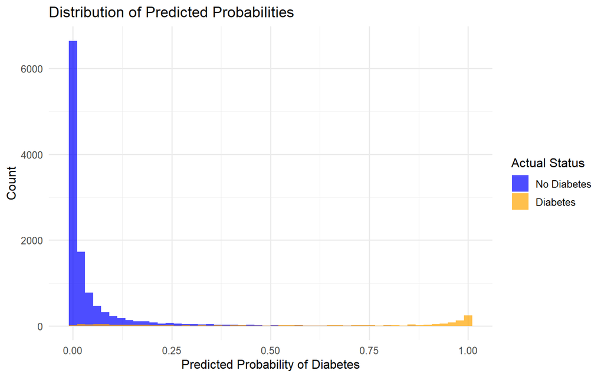

```r
pred_df <- data.frame(
  predicted_prob = test_probs,
  actual         = factor(test_data$diabetes,
                          labels = c("No Diabetes", "Diabetes"))
)

ggplot(pred_df, aes(x = predicted_prob, fill = actual)) +
  geom_histogram(bins = 50, alpha = 0.7, position = "identity") +
  scale_fill_manual(values = c("blue", "orange"), name = "Actual Status") +
  labs(title = "Distribution of Predicted Probabilities",
       x = "Predicted Probability of Diabetes",
       y = "Count") +
  theme_minimal(base_size = 12)
```

# Model Performance Summary

```r
perf_table <- data.frame(
  Metric    = c("Accuracy", "Sensitivity (Recall)", "Specificity",
                "Positive Predictive Value", "Negative Predictive Value",
                "AUC-ROC"),
  Value     = c(
    round(cm$overall["Accuracy"], 4),
    round(cm$byClass["Sensitivity"], 4),
    round(cm$byClass["Specificity"], 4),
    round(cm$byClass["Pos Pred Value"], 4),
    round(cm$byClass["Neg Pred Value"], 4),
    round(auc(roc_obj), 4)
  )
)

kable(perf_table, row.names = FALSE,
      caption = "Logistic Regression Model Performance Summary") %>%
  kable_styling(bootstrap_options = c("striped", "hover"),
                full_width = FALSE)
```

Logistic Regression Model Performance Summary

| Metric | Value |
| --- | --- |
| Accuracy | 0.9485 |
| Sensitivity (Recall) | 0.6327 |
| Specificity | 0.9872 |
| Positive Predictive Value | 0.8587 |
| Negative Predictive Value | 0.9564 |
| AUC-ROC | 0.9541 |

# Discussion

No surprises — HbA1c and blood glucose were the strongest predictors, exactly what you’d expect clinically. BMI and age also contributed. Hypertension and heart disease were present but likely overlap with other variables. The calibration test flagged a slight issue (p = 0.018), so the model’s predicted probabilities aren’t perfectly reliable. Also worth noting — it’s cross-sectional data, so we can’t claim causation, just association. Overall, solid baseline model. Could be improved by exploring interactions or trying more advanced algorithms.

# Conclusion

1.The logistic regression model did a great job predicting diabetes with 94.85% accuracy and an AUC of 0.954 — which is honestly impressive. 2.The two biggest factors driving predictions were HbA1c level and blood glucose level, which makes complete sense medically. Age and BMI also played a role. 3.The only real weak spot is sensitivity at 63% — meaning it misses about 1 in 3 actual diabetes cases, which isn’t ideal if you’re using this in a medical setting. 4.It’s a solid, well-performing model. Good enough for a baseline, but you’d want to improve how it catches positive cases before trusting it in the real world.